# Laboratorio 1, Parte 1

Roberto Aguilar

5/1/2021

# Paso 3

Primero accedemos a los discursos en formato .txt, que se encuentran almacenados en el directorio

```r
# Direccion de documentos en directorio

stevepath <- 'SteveJobsStanford.txt'
capath <- 'CATraspasoPresidencial.txt'
lgpath <- 'LGSTraspasoPresidencial.txt'

# Lectura de documentos en formato .txt

text_steve <- readLines(stevepath)
text_ca <- readLines(capath)
text_lg <- readLines(lgpath)
```

Ahora creamos una lista de documentos, donde cada doumento tendrá la estructura de un párrafo de discurso mediante la función **Corpus()**, de text mining

```r
# listado de documentos en discurso de Steve Jobs y ambos presidentes de Costa Rica

docs_st <- Corpus(VectorSource(text_steve))

docs_ca <- Corpus(VectorSource(text_ca))

docs_lg <- Corpus(VectorSource(text_lg))
```

# Paso 4

Ahora, nuestro interés está en insertar los datos de la forma más limpia posible. Como vimos anteriormente en el discurso de Steve Jobs, ciertos caracteres especiales fueron sustituídos por un “?” pero ahora previo al análisis necesitaremos transformarlos en espacios en blanco para hacer más eficiente el proceso. Para ello usaremos la función tm_map de text mining.

```r
# Se crea un tranformador de contenido que sustituye el caracter especial x que insertemos por un string de un espacio en blanco

toSpace <- content_transformer(function (x , pattern ) gsub(pattern, " ", x))

# Sustituye por cada vocal

toa <- content_transformer(function (x , pattern ) gsub(pattern, "a", x))
toe <- content_transformer(function (x , pattern ) gsub(pattern, "e", x))
toi <- content_transformer(function (x , pattern ) gsub(pattern, "i", x))
too <- content_transformer(function (x , pattern ) gsub(pattern, "o", x))
tou <- content_transformer(function (x , pattern ) gsub(pattern, "u", x))

# Sustituye por letra ñ

ton <- content_transformer(function (x , pattern ) gsub(pattern, "ñ", x))

# Aplicamos la transfomación para cada listado de documentos

# Steve Jobs
docs_st <- tm_map(docs_st, toSpace, "/")
docs_st <- tm_map(docs_st, toSpace, "@")
docs_st <- tm_map(docs_st, toSpace, "\\|")
docs_st <- tm_map(docs_st, toSpace, "Â€º")
docs_st <- tm_map(docs_st, toSpace, "Ã¿")

# Luis Guillermo Solis
docs_lg <- tm_map(docs_lg, toSpace, "/")
docs_lg <- tm_map(docs_lg, toSpace, "@")
docs_lg <- tm_map(docs_lg, toSpace, "\\|")
docs_lg <- tm_map(docs_lg, toa, c("Âš","Â š"))
docs_lg <- tm_map(docs_lg, toe, c("Â€", "Â€š"))
docs_lg <- tm_map(docs_lg, toi, c("Â¡", "Â¡š"))
docs_lg <- tm_map(docs_lg, too, c("Â¢","Â¢š"))
docs_lg <- tm_map(docs_lg, tou, c("Â£","Â£š"))
docs_lg <- tm_map(docs_lg, ton, "Â¤")
docs_lg <- tm_map(docs_lg, toe, "â€š")

# Carlos Alvarado
docs_ca <- tm_map(docs_ca, toSpace, "/")
docs_ca <- tm_map(docs_ca, toSpace, "@")
docs_ca <- tm_map(docs_ca, toSpace, "\\|")
docs_ca <- tm_map(docs_ca, toSpace, "“")
docs_ca <- tm_map(docs_ca, toSpace, "¡")
```

Primero hacemos ajustes al discurso de Steve Jobs

```r
# Convertir el texto en lower case
docs_st <- tm_map(docs_st, content_transformer(tolower))
# Eliminar numeros
docs_st <- tm_map(docs_st, removeNumbers)
# Eliminar stopwords en ingles
docs_st <- tm_map(docs_st, removeWords, stopwords("english"))
# Eliminar stopwords personalizados
docs_st <- tm_map(docs_st, removeWords, c("m", "ll", "ve", "s"))
# Eliminar puntuaciones
docs_st <- tm_map(docs_st, removePunctuation)
# Elimnar espacios extra en blanco
docs_st <- tm_map(docs_st, stripWhitespace)
# Eliminamos el caracter especial
docs_st <- tm_map(docs_st, toSpace, "ï»¿")
```

Lo hacemos para el discurso de Luis Guillermo Solis

```r
# Convertir el texto en lower case
docs_lg <- tm_map(docs_lg, content_transformer(tolower))
# Eliminar numeros
docs_lg <- tm_map(docs_lg, removeNumbers)
# Eliminar stopwords en ingles
docs_lg <- tm_map(docs_lg, removeWords, stopwords("spanish"))
# Eliminar puntuaciones
docs_lg <- tm_map(docs_lg, removePunctuation)
# Elimnar espacios extra en blanco
docs_lg <- tm_map(docs_lg, stripWhitespace)
# Ajustamos la "a + espacio"
docs_lg <- tm_map(docs_lg, toa, "â ")
# Eliminamos el caracter especial
docs_lg <- tm_map(docs_lg, toSpace, "ï»¿")
# Eliminar stopwords personalizados
docs_lg <- tm_map(docs_lg, removeWords, c("si", "ser", "sino", "cada", "tras", "la", "el", "las" , "los", "mas", "m�s" ,                                       "que", "con", "por", "del", "una", "como", "para", "sus", "cuando", "ese", "esa",
                                          "esta", "que,", "pero", "sin", "sino","mas"))
```

Y también lo hacemos para el discurso de Carlos Alvarado

```r
# Convertir el texto en lower case
docs_ca <- tm_map(docs_ca, content_transformer(tolower))
# Eliminar numeros
docs_ca <- tm_map(docs_ca, removeNumbers)
# Eliminar stopwords en ingles
docs_ca <- tm_map(docs_ca, removeWords, stopwords("spanish"))
# Eliminar stopwords personalizados
docs_ca <- tm_map(docs_ca, removeWords, c("si", "ser", "sino", "cada", "tras", "la", "el", "las" , "los", "mas", "m�s" ,                                       "que", "con", "por", "del", "una", "como", "para", "sus", "cuando", "ese", "esa",
                                          "esta", "que,", "pero", "sin", "sino"))
# Eliminar puntuaciones
docs_ca <- tm_map(docs_ca, removePunctuation)
# Elimnar espacios extra en blanco
docs_ca <- tm_map(docs_ca, stripWhitespace)
# Ajustamos la "a + espacio"
docs_ca <- tm_map(docs_ca, toa, "â ")
# Eliminamos el caracter especial
docs_ca <- tm_map(docs_ca, toSpace, "ï»¿")
```

# Paso 6

Ahora creamos una tabla matriz con la frecuencia de aparacion de palabras para cada discurso

```r
# Steve Jobs
dtmst <- TermDocumentMatrix(docs_st)
mst <- as.matrix(dtmst)
vst <- sort(rowSums(mst),decreasing=TRUE)
dst <- data.frame(word = names(vst),freq=vst)
head(dst, 10)
```

```
##            word freq
## life       life   17
## college college   14
## one         one    9
## years     years    9
## apple     apple    9
## just       just    8
## never     never    8
## dropped dropped    7
## months   months    7
## later     later    7
```

```r
# Luis Guillermo
dtmlg <- TermDocumentMatrix(docs_lg)
mlg <- as.matrix(dtmlg)
vlg <- sort(rowSums(mlg),decreasing=TRUE)
dlg <- data.frame(word = names(vlg),freq=vlg)
head(dlg, 10)
```

```
##                  word freq
## democracia democracia   13
## pueblo         pueblo   13
## pais             pais   12
## rica             rica   11
## costa           costa   10
## nacional     nacional    9
## tambien       tambien    9
## gobierno     gobierno    8
## sociedad     sociedad    8
## solo             solo    8
```

```r
# Carlos Alvarado
dtmca <- TermDocumentMatrix(docs_ca)
mca <- as.matrix(dtmca)
vca <- sort(rowSums(mca),decreasing=TRUE)
dca <- data.frame(word = names(vca),freq=vca)
head(dca, 10)
```

```
##                          word freq
## pais                     pais   22
## personas             personas   19
## debemos               debemos   17
## bienestar           bienestar   14
## bicentenario     bicentenario   14
## costa                   costa   14
## rica                     rica   14
## educacion           educacion   13
## todas                   todas   11
## costarricenses costarricenses   10
```

# Paso 7

Procedemos a ilustrar con un Wordcloud para cada discurso

### Discurso de Steve Jobs

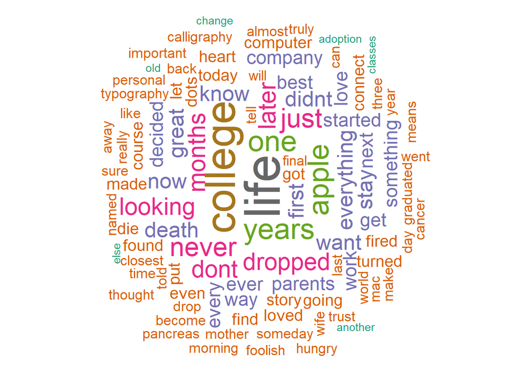

```r
set.seed(1234)
wordcloud(words = dst$word, freq = dst$freq, min.freq = 1, max.words=100,
          random.order=FALSE, rot.per=0.35, colors=brewer.pal(8, "Dark2"))
```

### Discurso de Luis Guillermo Solis

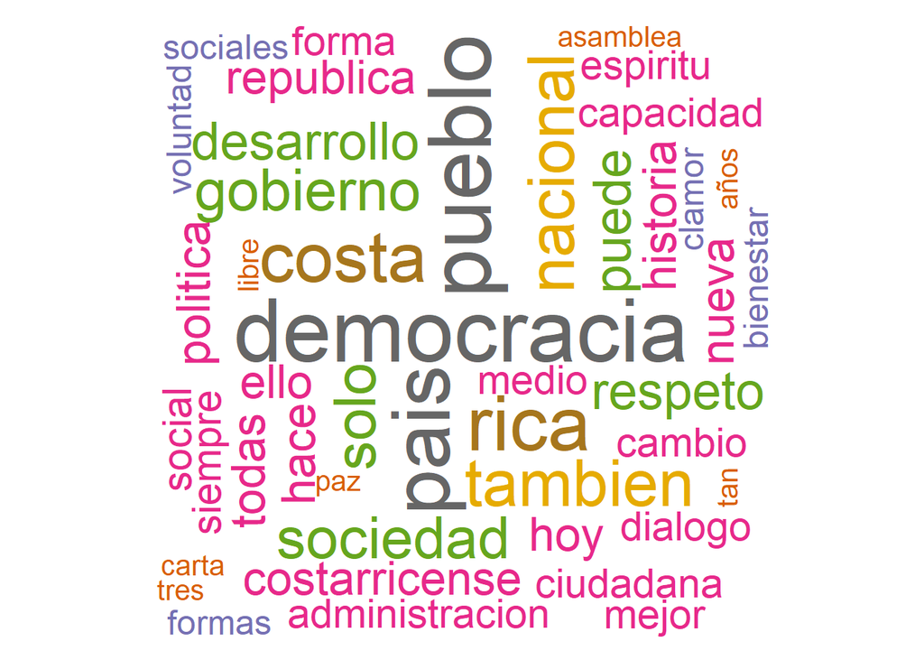

```r
set.seed(1234)
wordcloud(words = dlg$word, freq = dlg$freq, min.freq = 1, max.words=100,
          random.order=FALSE, rot.per=0.35, colors=brewer.pal(8, "Dark2"))
```

### Discurso de Carlos Alvarado

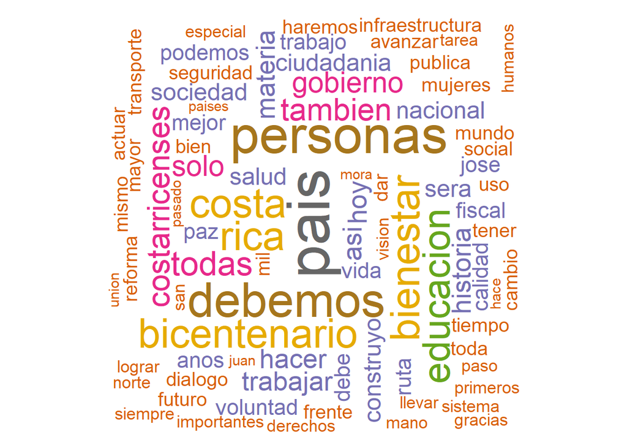

```r
set.seed(1234)
wordcloud(words = dca$word, freq = dca$freq, min.freq = 1, max.words=100,
          random.order=FALSE, rot.per=0.35, colors=brewer.pal(8, "Dark2"))
```

# Paso 8

Como análisis adicional, buscamos aquellas palabras que cómo mínimo aparezcan 4 veces dentros de cada discurso, la asociación de los términos

### Discurso de Steve Jobs

```r
# Frecuencia
findFreqTerms(dtmst, lowfreq = 4)
```

```
##  [1] "college"    "ever"       "just"       "life"       "never"
##  [6] "one"        "today"      "want"       "dots"       "first"
## [11] "story"      "dropped"    "months"     "course"     "decided"
## [16] "everything" "found"      "got"        "later"      "parents"
## [21] "put"        "started"    "best"       "didnt"      "going"
## [26] "looking"    "made"       "work"       "years"      "every"
## [31] "get"        "let"        "loved"      "turned"     "great"
## [36] "way"        "computer"   "connect"    "even"       "something"
## [41] "love"       "apple"      "company"    "fired"      "know"
## [46] "heart"      "next"       "now"        "dont"       "find"
## [51] "death"      "die"        "stay"
```

```r
# Asociación con "college"
findAssocs(dtmst, terms = "college", corlimit = 0.3)
```

```
## $college
##       minute       wanted      parents      decided        later    graduated
##         0.87         0.87         0.80         0.72         0.69         0.66
##      adopted     adoption       asking         baby   biological        birth
##         0.60         0.60         0.60         0.60         0.60         0.60
##         born          boy         call       except       father         girl
##         0.60         0.60         0.60         0.60         0.60         0.60
##    graduates         high       lawyer         list       middle       mother
##         0.60         0.60         0.60         0.60         0.60         0.60
##       papers       popped     promised      refused     relented         said
##         0.60         0.60         0.60         0.60         0.60         0.60
##       school          set         sign     strongly      student   unexpected
##         0.60         0.60         0.60         0.60         0.60         0.60
##        unwed      waiting        chose      couldnt    decisions     dropping
##         0.60         0.60         0.60         0.60         0.60         0.60
##    expensive       figure         idea     interest  interesting        money
##         0.60         0.60         0.60         0.60         0.60         0.60
##      naively         ones     required        saved      savings        scary
##         0.60         0.60         0.60         0.60         0.60         0.60
##     spending        spent     stanford         stop       taking      tuition
##         0.60         0.60         0.60         0.60         0.60         0.60
##        value workingclass        never      classes         back       course
##         0.60         0.60         0.53         0.50         0.46         0.44
##      dropped         felt     graduate        night        young        begin
##         0.43         0.37         0.37         0.37         0.37         0.37
##       entire         help       looked       pretty          see          six
##         0.37         0.37         0.37         0.37         0.37         0.37
##       months       really         time         drop
##         0.36         0.36         0.36         0.35
```

Ahora tenemos la frecuencia de forma visual

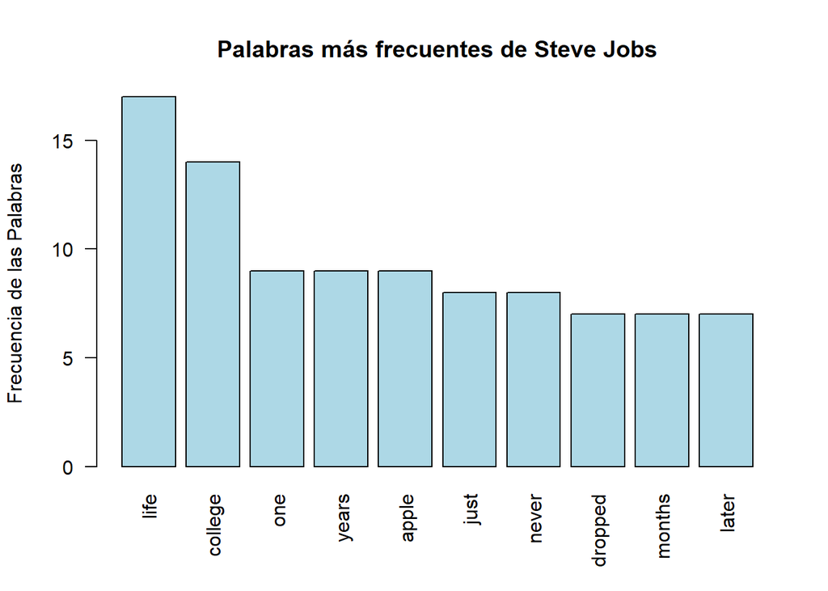

```r
# Grafico de barras
barplot(dst[1:10,]$freq, las = 2, names.arg = dst[1:10,]$word, col ="lightblue", main
="Palabras más frecuentes de Steve Jobs", ylab = "Frecuencia de las Palabras")
```

### Discurso de Luis Guillermo Solis

```r
# Frecuencia
findFreqTerms(dtmlg, lowfreq = 4)
```

```
##  [1] "administracion"  "bienestar"       "cambio"          "capacidad"
##  [5] "ciudadana"       "clamor"          "constitucion"    "corrupcion"
##  [9] "costa"           "costarricense"   "costarricenses"  "democracia"
## [13] "desarrollo"      "dialogo"         "ello"            "esfuerzo"
## [17] "espiritu"        "forma"           "formas"          "fuerzas"
## [21] "gobierno"        "hace"            "hacia"           "haremos"
## [25] "hicieron"        "himno"           "historia"        "hoy"
## [29] "mandato"         "medio"           "mejor"           "nacional"
## [33] "nueva"           "nuevas"          "pais"            "participacion"
## [37] "poder"           "politica"        "politicas"       "produccion"
## [41] "publica"         "publicas"        "publicos"        "pueblo"
## [45] "puede"           "pues"            "republica"       "respeto"
## [49] "responsabilidad" "rica"            "riqueza"         "siempre"
## [53] "social"          "sociales"        "sociedad"        "solo"
## [57] "tambien"         "todas"           "transparencia"   "voluntad"
```

Ahora tenemos la frecuencia de forma visual

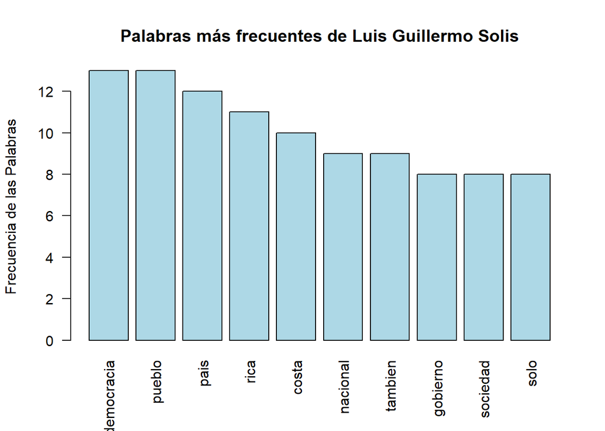

```r
# Grafico de barras
barplot(dlg[1:10,]$freq, las = 2, names.arg = dlg[1:10,]$word, col ="lightblue", main
="Palabras más frecuentes de Luis Guillermo Solis", ylab = "Frecuencia de las Palabras")
```

### Discurso de Carlos Alvarado

```r
# Frecuencia
findFreqTerms(dtmca, lowfreq = 4)
```

```
##  [1] "costarricenses"  "asi"             "bienestar"       "especial"
##  [5] "hoy"             "importantes"     "llevar"          "mayor"
##  [9] "mejor"           "mismo"           "pais"            "personas"
## [13] "todas"           "bicentenario"    "costa"           "lograr"
## [17] "mano"            "paso"            "rica"            "vida"
## [21] "mil"             "mujeres"         "primeros"        "solo"
## [25] "anos"            "tener"           "vision"          "paz"
## [29] "trabajo"         "construyo"       "siempre"         "ciudadania"
## [33] "jose"            "nacional"        "tarea"           "bien"
## [37] "dialogo"         "gracias"         "hacer"           "historia"
## [41] "voluntad"        "creacion"        "desarrollo"      "educacion"
## [45] "publica"         "dar"             "derechos"        "humanos"
## [49] "mundo"           "san"             "tambien"         "generacion"
## [53] "materia"         "fiscal"          "reforma"         "sistema"
## [57] "seguridad"       "social"          "avanzar"         "tiempo"
## [61] "haremos"         "sabemos"         "sera"            "trabajar"
## [65] "podemos"         "cambio"          "frente"          "gobierno"
## [69] "toda"            "norte"           "debemos"         "futuro"
## [73] "actuar"          "debe"            "sociedad"        "empleo"
## [77] "infraestructura" "salud"           "calidad"         "ruta"
## [81] "uso"             "manera"          "transporte"      "publico"
```

Ahora tenemos la frecuencia de forma visual

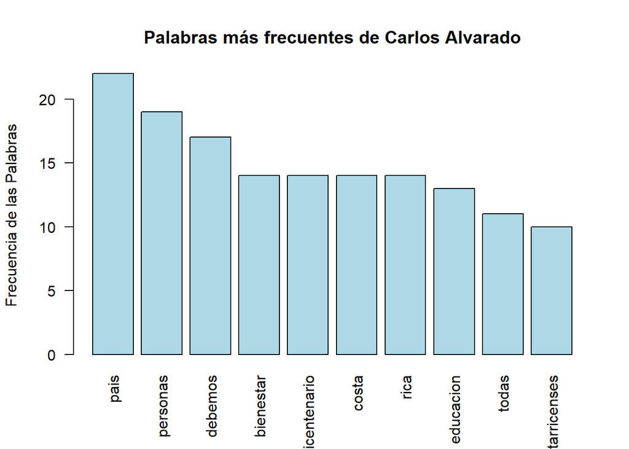

```r
# Grafico de barras
barplot(dca[1:10,]$freq, las = 2, names.arg = dca[1:10,]$word, col ="lightblue", main
="Palabras más frecuentes de Carlos Alvarado", ylab = "Frecuencia de las Palabras")
```